# Predicting using Exercise Manner

SS

Sunday, May 24, 2015

# Background

Using devices such as Jawbone Up, Nike FuelBand, and Fitbit it is now possible to collect a large amount of data about personal activity relatively inexpensively. These type of devices are part of the quantified self movement - a group of enthusiasts who take measurements about themselves regularly to improve their health, to find patterns in their behavior, or because they are tech geeks. One thing that people regularly do is quantify how much of a particular activity they do, but they rarely quantify how well they do it. In this project, goal is to predict the manner in which they did the exercise using data from accelerometers on the belt, forearm, arm, and dumbell of 6 participants.They were asked to perform barbell lifts correctly and incorrectly in 5 different ways;

A: exactly according to the specification B: throwing the elbows to the front C: lifting the dumbbell only halfway D: lowering the dumbbell only halfway E: throwing the hips to the front

```r
require(knitr); require(kernlab); require(caret);require(randomForest); require(ggplot2)
opts_chunk$set(cache=FALSE)
```

# Data Processing

```r
setInternet2(use = TRUE)
download.file('https://d396qusza40orc.cloudfront.net/predmachlearn/pml-training.csv', 'pml-training.csv')
download.file('https://d396qusza40orc.cloudfront.net/predmachlearn/pml-testing.csv','pml-test.csv')
training <- read.csv('pml-training.csv', na.strings= c("NA",""," ","#DIV/0!"))
testing <- read.csv('pml-test.csv', na.strings= c("NA",""," ","#DIV/0!"))
dim(training); dim(testing);table(training$classe);
```

```
## [1] 19622   160
```

```
## [1]  20 160
```

```
##
##    A    B    C    D    E
## 5580 3797 3422 3216 3607
```

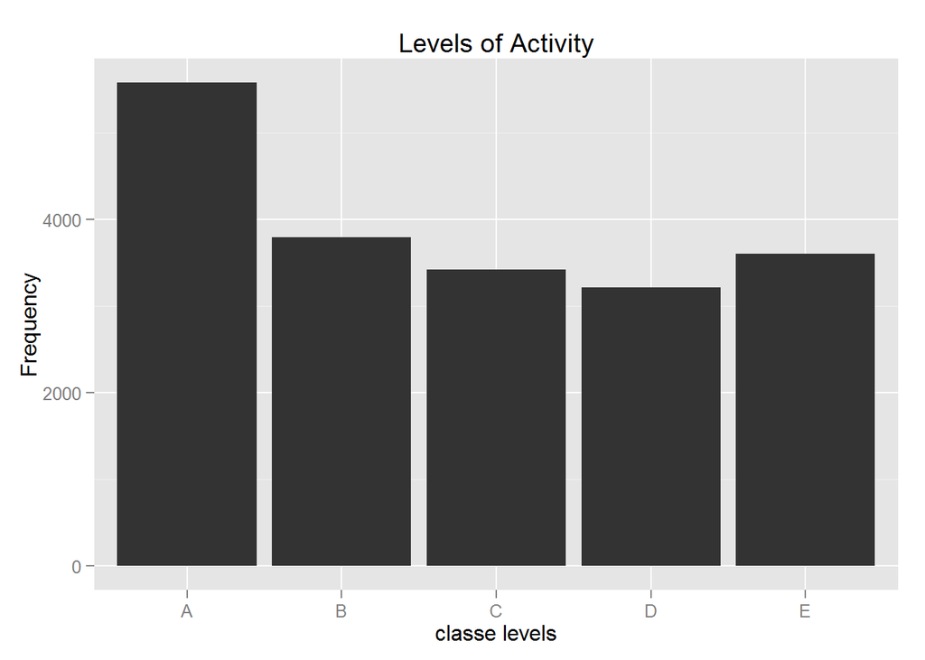

```r
qplot(training$classe, main="Levels of Activity", xlab="classe levels", ylab="Frequency")
```

Next, we will clean data before we create any model. There are lots of NA values and also first 7 variables are either identifier or timestamp or data not relating to belt, forearm, arm, and dumbell which does not contribute anything to model we are going to create.

```r
# cleaning data
na_training <- apply(training, 2, function(x) {sum(is.na(x))})
training_clean <- training[,which(na_training == 0)]

na_testing <- apply(testing, 2, function(x) {sum(is.na(x))})
testing_clean <- testing[,which(na_testing == 0)]
# removing id & timestamps
training_clean = training_clean[,-c(1:7)]
testing_clean = testing_clean[,-c(1:7)]
dim(training_clean); dim(testing_clean)
```

```
## [1] 19622    53
```

```
## [1] 20 53
```

# Splitting data into training and validation

Next, we will split data set into training and cross validation sets in a 60:40 ratio.

```r
# split the cleaned testing data into training and cross validation
set.seed(1234)
inTrain <- createDataPartition(y = training_clean$classe, p = 0.6, list = FALSE)
training_new <- training_clean[inTrain, ]
validation <- training_clean[-inTrain, ]
```

# Model

```r
#Fitting Random Forest
modFit <- randomForest(classe~ .,data=training_new, method="rf")
saveRDS(modFit, "rdsmodel.RDS")
modFit <- readRDS("rdsmodel.RDS")
modFit
```

```
##
## Call:
##  randomForest(formula = classe ~ ., data = training_new, method = "rf")
##                Type of random forest: classification
##                      Number of trees: 500
## No. of variables tried at each split: 7
##
##         OOB estimate of  error rate: 0.65%
## Confusion matrix:
##      A    B    C    D    E class.error
## A 3344    2    0    0    2 0.001194743
## B   16 2259    4    0    0 0.008775779
## C    0   17 2035    2    0 0.009250243
## D    0    0   23 1905    2 0.012953368
## E    0    0    3    6 2156 0.004157044
```

```r
#Important Variable
varImp(modFit)
```

```
##                        Overall
## roll_belt            741.65355
## pitch_belt           409.15848
## yaw_belt             552.66632
## total_accel_belt     107.74605
## gyros_belt_x          59.83696
## gyros_belt_y          63.32958
## gyros_belt_z         166.46126
## accel_belt_x          75.23579
## accel_belt_y          78.09609
## accel_belt_z         249.21136
## magnet_belt_x        152.15220
## magnet_belt_y        257.65160
## magnet_belt_z        246.54210
## roll_arm             197.53005
## pitch_arm            104.05554
## yaw_arm              143.59417
## total_accel_arm       62.33294
## gyros_arm_x           77.74852
## gyros_arm_y           79.26595
## gyros_arm_z           36.27296
## accel_arm_x          132.22233
## accel_arm_y           93.93047
## accel_arm_z           81.66408
## magnet_arm_x         153.31611
## magnet_arm_y         139.60997
## magnet_arm_z         111.81588
## roll_dumbbell        249.87949
## pitch_dumbbell       111.81256
## yaw_dumbbell         155.19546
## total_accel_dumbbell 159.93131
## gyros_dumbbell_x      79.09687
## gyros_dumbbell_y     158.12326
## gyros_dumbbell_z      55.94049
## accel_dumbbell_x     142.46626
## accel_dumbbell_y     256.16858
## accel_dumbbell_z     198.38738
## magnet_dumbbell_x    303.42982
## magnet_dumbbell_y    413.51985
## magnet_dumbbell_z    438.74107
## roll_forearm         354.85998
## pitch_forearm        472.62284
## yaw_forearm          101.49043
## total_accel_forearm   62.75164
## gyros_forearm_x       48.63577
## gyros_forearm_y       76.00116
## gyros_forearm_z       51.67170
## accel_forearm_x      190.69544
## accel_forearm_y       82.75738
## accel_forearm_z      143.44333
## magnet_forearm_x     123.18468
## magnet_forearm_y     131.24132
## magnet_forearm_z     174.46241
```

```r
#Confusion Matrix
trainingPred <- predict(modFit, training_new)
confusionMatrix(training_new$classe, trainingPred)
```

```
## Confusion Matrix and Statistics
##
##           Reference
## Prediction    A    B    C    D    E
##          A 3348    0    0    0    0
##          B    0 2279    0    0    0
##          C    0    0 2054    0    0
##          D    0    0    0 1930    0
##          E    0    0    0    0 2165
##
## Overall Statistics
##
##                Accuracy : 1
##                  95% CI : (0.9997, 1)
##     No Information Rate : 0.2843
##     P-Value [Acc > NIR] : < 2.2e-16
##
##                   Kappa : 1
##  Mcnemar's Test P-Value : NA
##
## Statistics by Class:
##
##                      Class: A Class: B Class: C Class: D Class: E
## Sensitivity            1.0000   1.0000   1.0000   1.0000   1.0000
## Specificity            1.0000   1.0000   1.0000   1.0000   1.0000
## Pos Pred Value         1.0000   1.0000   1.0000   1.0000   1.0000
## Neg Pred Value         1.0000   1.0000   1.0000   1.0000   1.0000
## Prevalence             0.2843   0.1935   0.1744   0.1639   0.1838
## Detection Rate         0.2843   0.1935   0.1744   0.1639   0.1838
## Detection Prevalence   0.2843   0.1935   0.1744   0.1639   0.1838
## Balanced Accuracy      1.0000   1.0000   1.0000   1.0000   1.0000
```

# Cross-validation

Next, we will use model in remaining 40% of data to classify prediction. A confusion matrix shows that the accuracy of the model.

```r
# crossvalidate the model using the remaining 40% of data
crossVal <- predict(modFit, validation)
confusionMatrix(validation$classe, crossVal)
```

```
## Confusion Matrix and Statistics
##
##           Reference
## Prediction    A    B    C    D    E
##          A 2232    0    0    0    0
##          B   10 1503    5    0    0
##          C    0    9 1356    3    0
##          D    0    0   19 1265    2
##          E    0    0    2    3 1437
##
## Overall Statistics
##
##                Accuracy : 0.9932
##                  95% CI : (0.9912, 0.9949)
##     No Information Rate : 0.2858
##     P-Value [Acc > NIR] : < 2.2e-16
##
##                   Kappa : 0.9915
##  Mcnemar's Test P-Value : NA
##
## Statistics by Class:
##
##                      Class: A Class: B Class: C Class: D Class: E
## Sensitivity            0.9955   0.9940   0.9812   0.9953   0.9986
## Specificity            1.0000   0.9976   0.9981   0.9968   0.9992
## Pos Pred Value         1.0000   0.9901   0.9912   0.9837   0.9965
## Neg Pred Value         0.9982   0.9986   0.9960   0.9991   0.9997
## Prevalence             0.2858   0.1927   0.1761   0.1620   0.1834
## Detection Rate         0.2845   0.1916   0.1728   0.1612   0.1832
## Detection Prevalence   0.2845   0.1935   0.1744   0.1639   0.1838
## Balanced Accuracy      0.9978   0.9958   0.9897   0.9960   0.9989
```

# Predictions

We will then use this model to predit the classifications of the 20 results of testing data.

```r
# predict the classes of the test set
predictTest <- predict(modFit, testing_clean)
predictTest
```

```
##  1  2  3  4  5  6  7  8  9 10 11 12 13 14 15 16 17 18 19 20
##  B  A  B  A  A  E  D  B  A  A  B  C  B  A  E  E  A  B  B  B
## Levels: A B C D E
```

# Conclusions

Using random forest model we can predict how well a person is preforming an excercise.